## Title: Data Analysis

## Enrollment number: 22002170220021

## Subject : FCSP-2

# Problem Statement: Provide Insights to the Marketing Team in Food & Beverage Industry

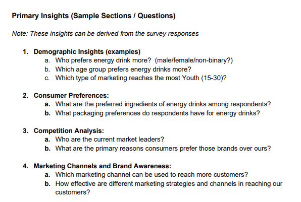

### Importing required libraries

```python
import pandas as pd
import matplotlib.pyplot as plt
import seaborn as sns
import warnings

#to ignore all the warnings
warnings.filterwarnings("ignore")
```

### Importing csv files

```python
survey_df = pd.read_csv('Dataset/fact_survey_responses.csv')
```

```python
respondants_df = pd.read_csv('Dataset/dim_repondents.csv')
```

```python
city_df = pd.read_csv('Dataset/dim_cities.csv')
```

### Merging csv files based on common columns between tables

```python
two_tables = pd.merge(left=survey_df,right=respondants_df,how='outer',on='Respondent_ID')
```

```python
two_tables.head()
```

|  | Response_ID | Respondent_ID | Consume_frequency | Consume_time | Consume_reason | Heard_before | Brand_perception | General_perception | Tried_before | Taste_experience | ... | Marketing_channels | Packaging_preference | Limited_edition_packaging | Price_range | Purchase_location | Typical_consumption_situations | Name | Age | Gender | City_ID |
| --- | --- | --- | --- | --- | --- | --- | --- | --- | --- | --- | --- | --- | --- | --- | --- | --- | --- | --- | --- | --- | --- |
| 0 | 103001 | 120031 | 2-3 times a week | To stay awake during work/study | Increased energy and focus | Yes | Neutral | Not sure | No | 5 | ... | TV commercials | Compact and portable cans | Yes | 50-99 | Supermarkets | Studying/working late | Aniruddh Issac | 15-18 | Female | CT117 |
| 1 | 103002 | 120032 | 2-3 times a month | Throughout the day | To boost performance | No | Neutral | Not sure | No | 5 | ... | Print media | Compact and portable cans | No | 50-99 | Supermarkets | Sports/exercise | Trisha Rout | 19-30 | Male | CT118 |
| 2 | 103003 | 120033 | Rarely | Before exercise | Increased energy and focus | No | Neutral | Not sure | No | 2 | ... | Online ads | Innovative bottle design | Not Sure | 100-150 | Supermarkets | Studying/working late | Yuvraj Virk | 15-18 | Male | CT116 |
| 3 | 103004 | 120034 | 2-3 times a week | To stay awake during work/study | To boost performance | No | Positive | Dangerous | Yes | 5 | ... | Online ads | Compact and portable cans | No | Above 150 | Supermarkets | Sports/exercise | Pranay Chand | 31-45 | Female | CT113 |
| 4 | 103005 | 120035 | Daily | To stay awake during work/study | Increased energy and focus | Yes | Neutral | Effective | Yes | 5 | ... | Online ads | Compact and portable cans | Yes | 100-150 | Online retailers | Studying/working late | Mohanlal Joshi | 19-30 | Female | CT120 |

5 rows × 27 columns

```python
full_df = pd.merge(left=two_tables,right=city_df,how='outer',on='City_ID')
```

```python
full_df.head()
```

|  | Response_ID | Respondent_ID | Consume_frequency | Consume_time | Consume_reason | Heard_before | Brand_perception | General_perception | Tried_before | Taste_experience | ... | Limited_edition_packaging | Price_range | Purchase_location | Typical_consumption_situations | Name | Age | Gender | City_ID | City | Tier |
| --- | --- | --- | --- | --- | --- | --- | --- | --- | --- | --- | --- | --- | --- | --- | --- | --- | --- | --- | --- | --- | --- |
| 0 | 103001 | 120031 | 2-3 times a week | To stay awake during work/study | Increased energy and focus | Yes | Neutral | Not sure | No | 5 | ... | Yes | 50-99 | Supermarkets | Studying/working late | Aniruddh Issac | 15-18 | Female | CT117 | Ahmedabad | Tier 2 |
| 1 | 103025 | 120055 | Once a week | Before exercise | To enhance sports performance | Yes | Neutral | Effective | Yes | 3 | ... | No | Above 150 | Gyms and fitness centers | Studying/working late | Umang Sarkar | 31-45 | Non-binary | CT117 | Ahmedabad | Tier 2 |
| 2 | 103027 | 120057 | Daily | Before exercise | To boost performance | No | Neutral | Healthy | No | 2 | ... | No | 50-99 | Online retailers | Sports/exercise | Kanav Thaman | 19-30 | Male | CT117 | Ahmedabad | Tier 2 |
| 3 | 103048 | 120078 | Rarely | Before exercise | To enhance sports performance | No | Neutral | Dangerous | No | 3 | ... | Not Sure | 100-150 | Supermarkets | Sports/exercise | Suhana Ramakrishnan | 19-30 | Female | CT117 | Ahmedabad | Tier 2 |
| 4 | 103068 | 120098 | Daily | Throughout the day | Other | No | Neutral | Effective | No | 4 | ... | Yes | 100-150 | Other | Studying/working late | Saira Sridhar | 19-30 | Male | CT117 | Ahmedabad | Tier 2 |

5 rows × 29 columns

## 1. Demographic Insights (examples)

### a.Who prefers energy drink more? (male/female/non-binary?)

```python
# finding out the columns
```

```python
full_df.columns
```

```
Index(['Response_ID', 'Respondent_ID', 'Consume_frequency', 'Consume_time',
       'Consume_reason', 'Heard_before', 'Brand_perception',
       'General_perception', 'Tried_before', 'Taste_experience',
       'Reasons_preventing_trying', 'Current_brands',
       'Reasons_for_choosing_brands', 'Improvements_desired',
       'Ingredients_expected', 'Health_concerns',
       'Interest_in_natural_or_organic', 'Marketing_channels',
       'Packaging_preference', 'Limited_edition_packaging', 'Price_range',
       'Purchase_location', 'Typical_consumption_situations', 'Name', 'Age',
       'Gender', 'City_ID', 'City', 'Tier'],
      dtype='object')
```

```python
# grouping the dataset by consume frequency and gender
```

```python
energy_pref = full_df.groupby(['Consume_frequency','Gender']).size().unstack()
```

```python
energy_pref
```

| Gender Consume_frequency | Female | Male | Non-binary |
| --- | --- | --- | --- |
| 2-3 times a month | 549 | 968 | 96 |
| 2-3 times a week | 1217 | 2094 | 180 |
| Daily | 466 | 817 | 63 |
| Once a week | 561 | 973 | 75 |
| Rarely | 662 | 1186 | 93 |

### Plotting the data

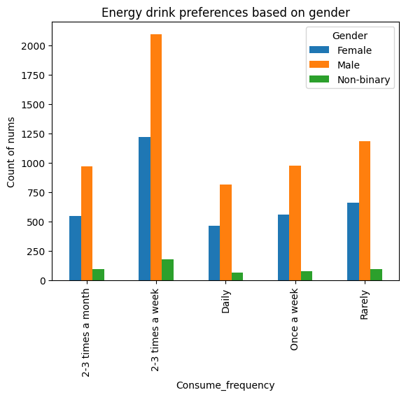

```python
plt.figure(figsize=(12,8))
energy_pref.plot(kind='bar')
plt.ylabel("Count of nums")
plt.title("Energy drink preferences based on gender")
# plt.legend(loc=(1.1,0.75))
plt.show()
```

### Observations :

- people more likly to have energy drink 2-3 times a week
- male are more prone to energy drink than others

### b. Which age group prefers energy drinks more?

```python
age_df = full_df.groupby(['Consume_frequency','Age']).size().unstack()
```

```python
age_df
```

| Age Consume_frequency | 15-18 | 19-30 | 31-45 | 46-65 | 65+ |
| --- | --- | --- | --- | --- | --- |
| 2-3 times a month | 232 | 891 | 398 | 66 | 26 |
| 2-3 times a week | 539 | 1917 | 809 | 155 | 71 |
| Daily | 196 | 736 | 348 | 42 | 24 |
| Once a week | 244 | 888 | 361 | 86 | 30 |
| Rarely | 277 | 1088 | 460 | 77 | 39 |

### Plotting the result

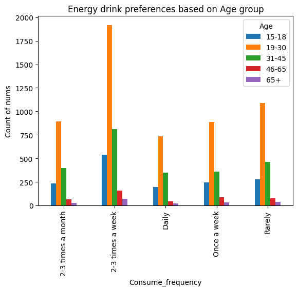

```python
plt.figure(figsize=(12,8))
age_df.plot(kind='bar')
plt.ylabel("Count of nums")
plt.title("Energy drink preferences based on Age group")
# plt.legend(loc=(1.1,0.75))
plt.show()
```

### Observations:

- There is a increasing trend in having energy drinks from age 15 to 30
- People with age group of 19-30 are the highest consumers of energy drink
- after 30 people are less probable to have energy drink

### c. Which type of marketing reaches the most Youth (15-30)?

### Extracting coustomers within the range of 15-30 then finding the frequency

```python
youth_df = full_df.loc[(full_df["Age"]=='15-18') | (full_df["Age"]=='19-30'), 'Marketing_channels'].value_counts()
```

```python
youth_df
```

```
Online ads            3373
TV commercials        1785
Outdoor billboards     702
Other                  702
Print media            446
Name: Marketing_channels, dtype: int64
```

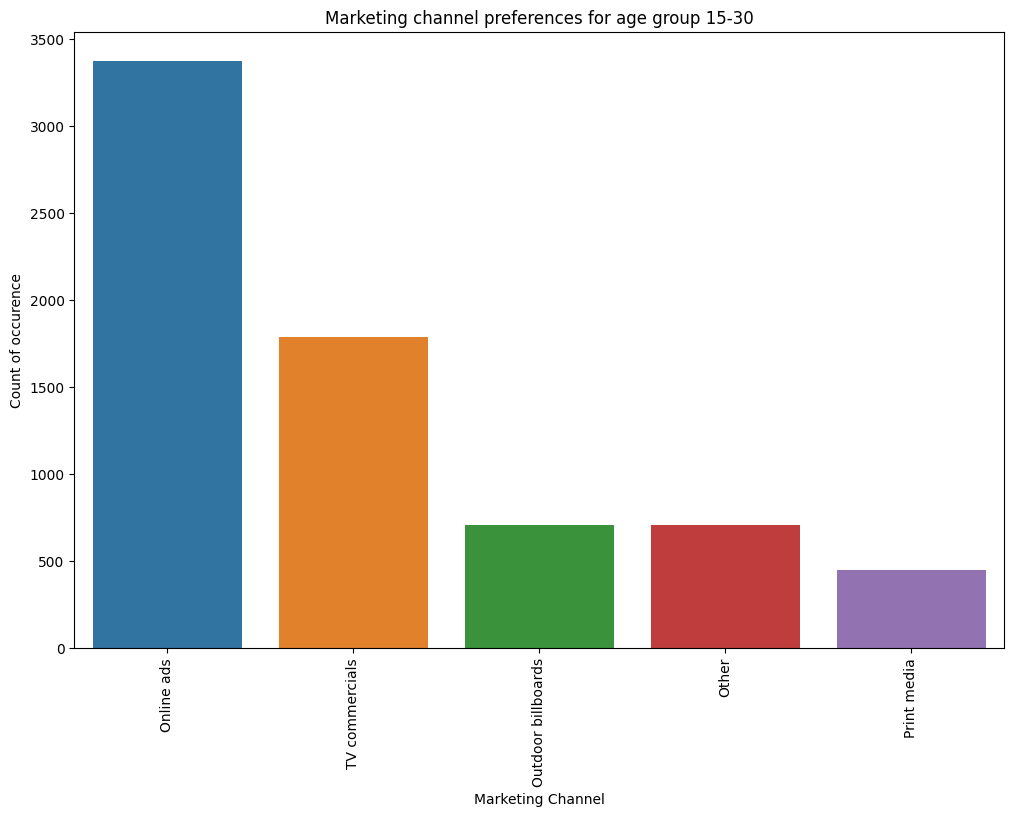

```python
plt.figure(figsize=(12,8))
sns.barplot(x=youth_df.index,y=youth_df.values)
plt.xticks(rotation = 90)
plt.xlabel("Marketing Channel")
plt.ylabel("Count of occurence")
plt.title("Marketing channel preferences for age group 15-30")
plt.show()
```

### Observations:

- online ads are reaching to more people

## 2. Consumer Preferences:

### a. What are the preferred ingredients of energy drinks among respondents?

```python
# Finding the frequency of ingredients
```

```python
ingredients_pref = full_df['Ingredients_expected'].value_counts()
```

```python
ingredients_pref
```

```
Caffeine    3896
Vitamins    2534
Sugar       2017
Guarana     1553
Name: Ingredients_expected, dtype: int64
```

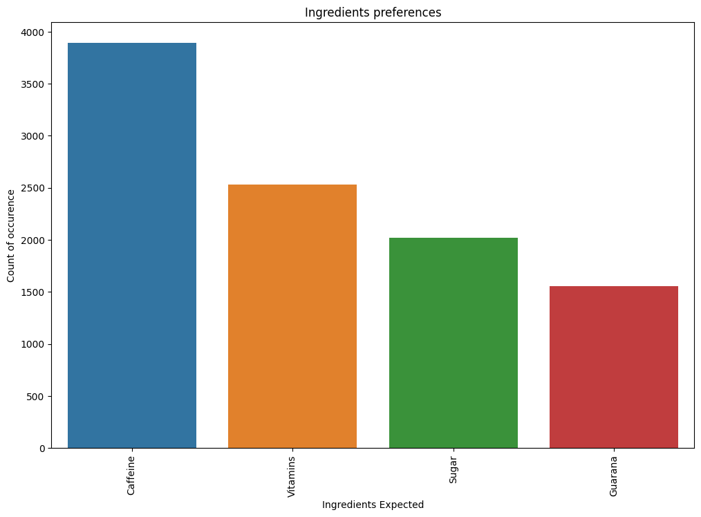

```python
plt.figure(figsize=(12,8))
sns.barplot(x=ingredients_pref.index,y=ingredients_pref.values)
plt.xticks(rotation = 90)
plt.xlabel("Ingredients Expected")
plt.ylabel("Count of occurence")
plt.title("Ingredients preferences")
plt.show()
```

### Observations :

- People ask for Caffeine more than vitamins

### b. What packaging preferences do respondents have for energy drinks?

```python
pack_df = full_df['Packaging_preference'].value_counts()
```

```python
pack_df
```

```
Compact and portable cans    3984
Innovative bottle design     3047
Collectible packaging        1501
Eco-friendly design           983
Other                         485
Name: Packaging_preference, dtype: int64
```

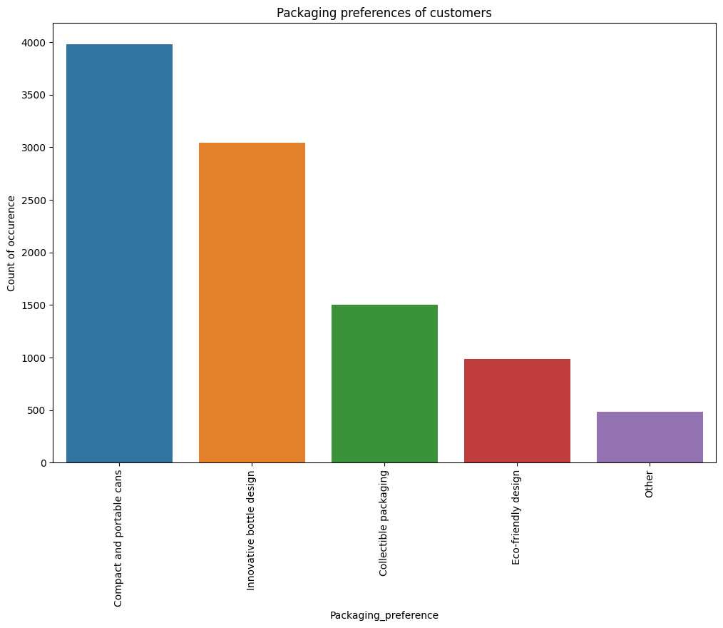

```python
plt.figure(figsize=(12,8))
sns.barplot(x=pack_df.index,y=pack_df.values)
plt.xticks(rotation = 90)
plt.xlabel("Packaging_preference")
plt.ylabel("Count of occurence")
plt.title("Packaging preferences of customers")
plt.show()
```

### Observations:

- In packaging people are liking to have Compact and portable cans

## 3. Competition Analysis:

### a. Who are the current market leaders?

```python
lead_df = full_df['Current_brands'].value_counts()
```

```python
lead_df
```

```
Cola-Coka    2538
Bepsi        2112
Gangster     1854
Blue Bull    1058
CodeX         980
Sky 9         979
Others        479
Name: Current_brands, dtype: int64
```

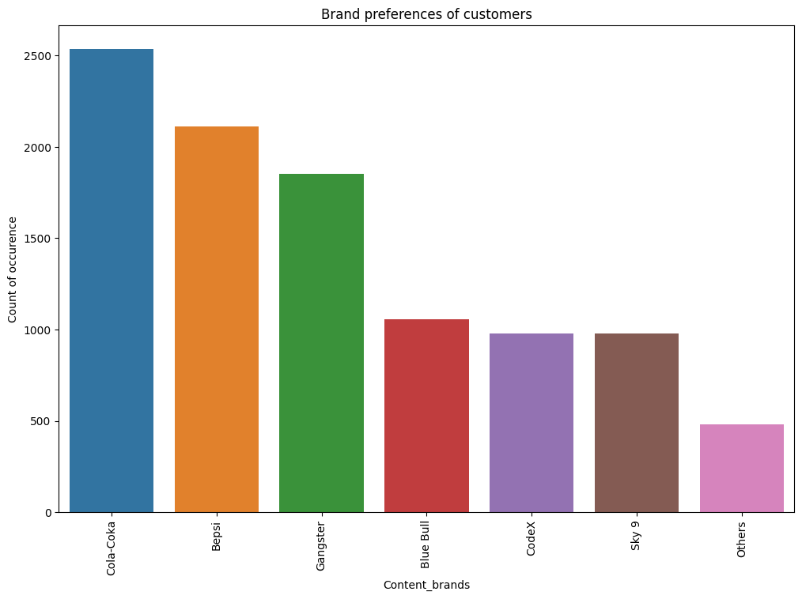

```python
plt.figure(figsize=(12,8))
sns.barplot(x=lead_df.index,y=lead_df.values)
plt.xticks(rotation = 90)
plt.xlabel("Content_brands")
plt.ylabel("Count of occurence")
plt.title("Brand preferences of customers")
plt.show()
```

```python
market_share_df = full_df['Current_brands'].value_counts(normalize=True)*100
```

```python
market_share_df
```

```
Cola-Coka    25.38
Bepsi        21.12
Gangster     18.54
Blue Bull    10.58
CodeX         9.80
Sky 9         9.79
Others        4.79
Name: Current_brands, dtype: float64
```

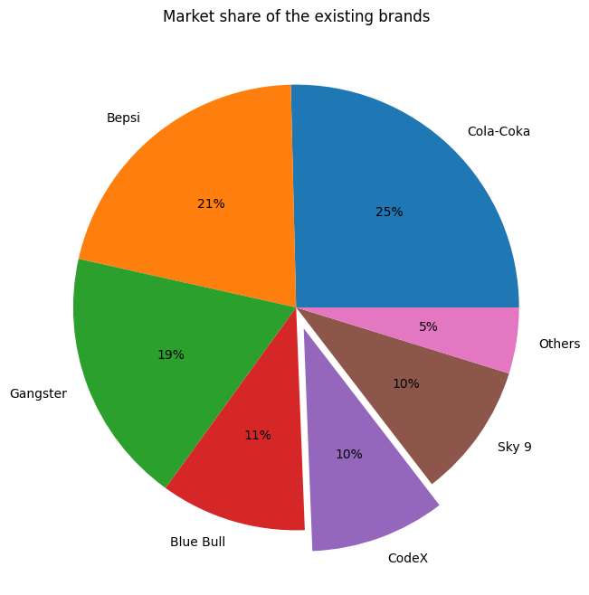

```python
plt.figure(figsize = (12,8))
plt.pie(market_share_df,labels=market_share_df.index, autopct='%.0f%%',explode=[0,0,0,0,0.10,0,0])
plt.title("Market share of the existing brands")
```

### Observations:

- cola-coka is leading the market!
- cola-coka is occupying 25% of the market closely followed by bepsi by 21%

### b. What are the primary reasons consumers prefer those brands over ours?

```python
full_df.columns
```

```
Index(['Response_ID', 'Respondent_ID', 'Consume_frequency', 'Consume_time',
       'Consume_reason', 'Heard_before', 'Brand_perception',
       'General_perception', 'Tried_before', 'Taste_experience',
       'Reasons_preventing_trying', 'Current_brands',
       'Reasons_for_choosing_brands', 'Improvements_desired',
       'Ingredients_expected', 'Health_concerns',
       'Interest_in_natural_or_organic', 'Marketing_channels',
       'Packaging_preference', 'Limited_edition_packaging', 'Price_range',
       'Purchase_location', 'Typical_consumption_situations', 'Name', 'Age',
       'Gender', 'City_ID', 'City', 'Tier'],
      dtype='object')
```

**Segregating customers whose current brand is not codeX**

```python
cus_of_other_brand = full_df.loc[full_df['Current_brands']!='CodeX',:]
```

```python
cus_of_other_brand.head()
```

|  | Response_ID | Respondent_ID | Consume_frequency | Consume_time | Consume_reason | Heard_before | Brand_perception | General_perception | Tried_before | Taste_experience | ... | Limited_edition_packaging | Price_range | Purchase_location | Typical_consumption_situations | Name | Age | Gender | City_ID | City | Tier |
| --- | --- | --- | --- | --- | --- | --- | --- | --- | --- | --- | --- | --- | --- | --- | --- | --- | --- | --- | --- | --- | --- |
| 0 | 103001 | 120031 | 2-3 times a week | To stay awake during work/study | Increased energy and focus | Yes | Neutral | Not sure | No | 5 | ... | Yes | 50-99 | Supermarkets | Studying/working late | Aniruddh Issac | 15-18 | Female | CT117 | Ahmedabad | Tier 2 |
| 1 | 103025 | 120055 | Once a week | Before exercise | To enhance sports performance | Yes | Neutral | Effective | Yes | 3 | ... | No | Above 150 | Gyms and fitness centers | Studying/working late | Umang Sarkar | 31-45 | Non-binary | CT117 | Ahmedabad | Tier 2 |
| 2 | 103027 | 120057 | Daily | Before exercise | To boost performance | No | Neutral | Healthy | No | 2 | ... | No | 50-99 | Online retailers | Sports/exercise | Kanav Thaman | 19-30 | Male | CT117 | Ahmedabad | Tier 2 |
| 3 | 103048 | 120078 | Rarely | Before exercise | To enhance sports performance | No | Neutral | Dangerous | No | 3 | ... | Not Sure | 100-150 | Supermarkets | Sports/exercise | Suhana Ramakrishnan | 19-30 | Female | CT117 | Ahmedabad | Tier 2 |
| 4 | 103068 | 120098 | Daily | Throughout the day | Other | No | Neutral | Effective | No | 4 | ... | Yes | 100-150 | Other | Studying/working late | Saira Sridhar | 19-30 | Male | CT117 | Ahmedabad | Tier 2 |

5 rows × 29 columns

**Finding the issue**

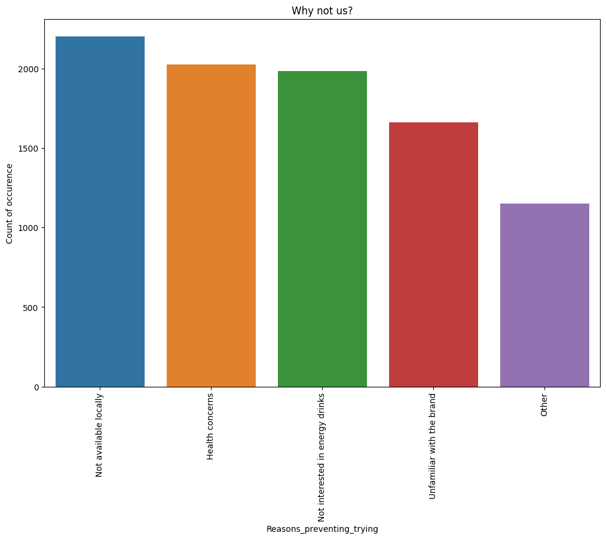

```python
iss_df = cus_of_other_brand['Reasons_preventing_trying'].value_counts()

plt.figure(figsize=(12,8))
sns.barplot(x=iss_df.index,y=iss_df.values)
plt.xticks(rotation = 90)
plt.xlabel("Reasons_preventing_trying")
plt.ylabel("Count of occurence")
plt.title("Why not us?")
plt.show()
```

### Observations:

- The prime reason is that the brand is not available locally

**Finding out the reason to choose other brands**

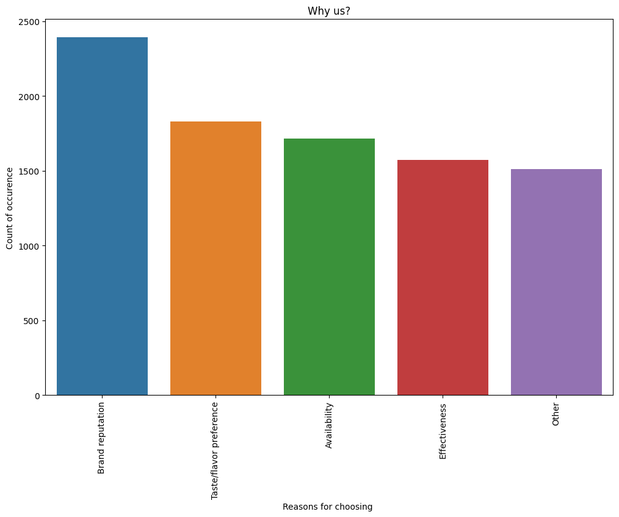

```python
other_brands_df = cus_of_other_brand['Reasons_for_choosing_brands'].value_counts()

plt.figure(figsize=(12,8))
sns.barplot(x=other_brands_df.index,y=other_brands_df.values)
plt.xticks(rotation = 90)
plt.xlabel("Reasons for choosing ")
plt.ylabel("Count of occurence")
plt.title("Why us?")
plt.show()
```

### Observations :

- Brand reputation is the demanding factor

## 4. Marketing Channels and Brand Awareness:

### a. Which marketing channel can be used to reach more customers?

**trying to find what marketing source is bringing customers to other companies?**

```python
ms_counts = full_df['Marketing_channels'].value_counts()
```

```python
cus_of_codex= full_df.loc[full_df['Current_brands']=="CodeX",:]
```

```python
cus_of_codex.head()
```

|  | Response_ID | Respondent_ID | Consume_frequency | Consume_time | Consume_reason | Heard_before | Brand_perception | General_perception | Tried_before | Taste_experience | ... | Limited_edition_packaging | Price_range | Purchase_location | Typical_consumption_situations | Name | Age | Gender | City_ID | City | Tier |
| --- | --- | --- | --- | --- | --- | --- | --- | --- | --- | --- | --- | --- | --- | --- | --- | --- | --- | --- | --- | --- | --- |
| 10 | 103154 | 120184 | 2-3 times a month | Before exercise | Increased energy and focus | No | Negative | Healthy | No | 5 | ... | Yes | Below 50 | Supermarkets | Sports/exercise | Amani Krishnamurthy | 19-30 | Male | CT117 | Ahmedabad | Tier 2 |
| 11 | 103155 | 120185 | 2-3 times a week | For mental alertness | To boost performance | Yes | Positive | Not sure | No | 4 | ... | No | 50-99 | Online retailers | Sports/exercise | Aarav Rana | 19-30 | Male | CT117 | Ahmedabad | Tier 2 |
| 25 | 103441 | 120471 | Rarely | For mental alertness | Increased energy and focus | Yes | Negative | Dangerous | No | 3 | ... | Not Sure | Below 50 | Online retailers | Sports/exercise | Yuvraj Acharya | 31-45 | Female | CT117 | Ahmedabad | Tier 2 |
| 27 | 103490 | 120520 | Rarely | Before exercise | Increased energy and focus | Yes | Negative | Effective | No | 2 | ... | Not Sure | 50-99 | Online retailers | Sports/exercise | Miraya D’Alia | 19-30 | Female | CT117 | Ahmedabad | Tier 2 |
| 32 | 103604 | 120634 | Rarely | For mental alertness | To combat fatigue | Yes | Neutral | Not sure | No | 4 | ... | No | Above 150 | Other | Studying/working late | Faiyaz Tank | 19-30 | Female | CT117 | Ahmedabad | Tier 2 |

5 rows × 29 columns

```python
codex_counts = cus_of_codex['Marketing_channels'].value_counts()
```

```python
codex_counts
```

```
Online ads            411
TV commercials        261
Outdoor billboards    119
Other                 116
Print media            73
Name: Marketing_channels, dtype: int64
```

[output not shown]

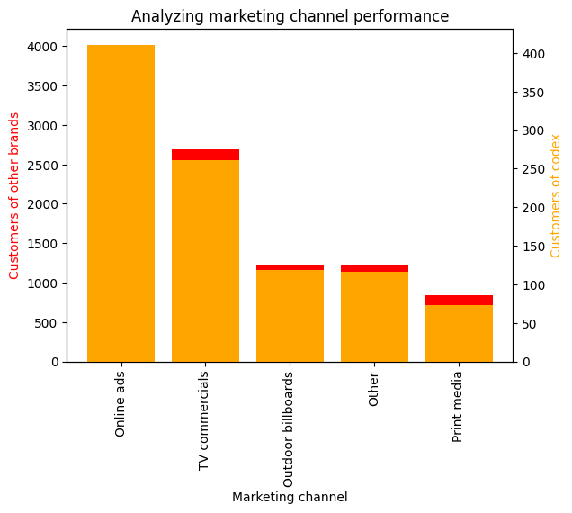

```python
fig,ax1 = plt.subplots()
plt.title("Analyzing marketing channel performance")
ax2 = ax1.twinx()
ax1.bar(ms_counts.index,ms_counts.values,color='red')
ax2.bar(ms_counts.index,codex_counts.values,color='orange')

ax1.set_xlabel("Marketing channel")
ax1.set_ylabel("Customers of other brands",color='red')
ax2.set_ylabel("Customers of codex",color='orange')
ax1.set_xticklabels(ms_counts.index,rotation='vertical')
```

### Observations:

- online ads is reaching more people

### b. How effective are different marketing strategies and channels in reaching our customers?

### focusing on the codex customers

```python
codex_cust = full_df[full_df['Current_brands']=='CodeX']
codex_cust
```

|  | Response_ID | Respondent_ID | Consume_frequency | Consume_time | Consume_reason | Heard_before | Brand_perception | General_perception | Tried_before | Taste_experience | ... | Limited_edition_packaging | Price_range | Purchase_location | Typical_consumption_situations | Name | Age | Gender | City_ID | City | Tier |
| --- | --- | --- | --- | --- | --- | --- | --- | --- | --- | --- | --- | --- | --- | --- | --- | --- | --- | --- | --- | --- | --- |
| 10 | 103154 | 120184 | 2-3 times a month | Before exercise | Increased energy and focus | No | Negative | Healthy | No | 5 | ... | Yes | Below 50 | Supermarkets | Sports/exercise | Amani Krishnamurthy | 19-30 | Male | CT117 | Ahmedabad | Tier 2 |
| 11 | 103155 | 120185 | 2-3 times a week | For mental alertness | To boost performance | Yes | Positive | Not sure | No | 4 | ... | No | 50-99 | Online retailers | Sports/exercise | Aarav Rana | 19-30 | Male | CT117 | Ahmedabad | Tier 2 |
| 25 | 103441 | 120471 | Rarely | For mental alertness | Increased energy and focus | Yes | Negative | Dangerous | No | 3 | ... | Not Sure | Below 50 | Online retailers | Sports/exercise | Yuvraj Acharya | 31-45 | Female | CT117 | Ahmedabad | Tier 2 |
| 27 | 103490 | 120520 | Rarely | Before exercise | Increased energy and focus | Yes | Negative | Effective | No | 2 | ... | Not Sure | 50-99 | Online retailers | Sports/exercise | Miraya D’Alia | 19-30 | Female | CT117 | Ahmedabad | Tier 2 |
| 32 | 103604 | 120634 | Rarely | For mental alertness | To combat fatigue | Yes | Neutral | Not sure | No | 4 | ... | No | Above 150 | Other | Studying/working late | Faiyaz Tank | 19-30 | Female | CT117 | Ahmedabad | Tier 2 |
| ... | ... | ... | ... | ... | ... | ... | ... | ... | ... | ... | ... | ... | ... | ... | ... | ... | ... | ... | ... | ... | ... |
| 9965 | 112251 | 129281 | Rarely | Throughout the day | To enhance sports performance | No | Neutral | Effective | No | 3 | ... | Not Sure | 50-99 | Supermarkets | Other | Rasha Chaudhary | 15-18 | Male | CT111 | Delhi | Tier 1 |
| 9966 | 112290 | 129320 | 2-3 times a week | Before exercise | Increased energy and focus | Yes | Neutral | Not sure | No | 4 | ... | No | 100-150 | Supermarkets | Sports/exercise | Kavya Mammen | 19-30 | Male | CT111 | Delhi | Tier 1 |
| 9974 | 112403 | 129433 | Daily | To stay awake during work/study | To combat fatigue | No | Neutral | Effective | No | 3 | ... | No | Below 50 | Supermarkets | Sports/exercise | Bhavin Srivastava | 31-45 | Male | CT111 | Delhi | Tier 1 |
| 9982 | 112534 | 129564 | 2-3 times a month | Before exercise | To combat fatigue | Yes | Neutral | Dangerous | No | 4 | ... | No | 100-150 | Supermarkets | Studying/working late | Dharmajan Karpe | 31-45 | Male | CT111 | Delhi | Tier 1 |
| 9991 | 112736 | 129766 | 2-3 times a month | To stay awake during work/study | To combat fatigue | No | Positive | Healthy | No | 5 | ... | No | 100-150 | Online retailers | Sports/exercise | Prerak Edwin | 19-30 | Non-binary | CT111 | Delhi | Tier 1 |

980 rows × 29 columns

```python
full_df.columns
```

```
Index(['Response_ID', 'Respondent_ID', 'Consume_frequency', 'Consume_time',
       'Consume_reason', 'Heard_before', 'Brand_perception',
       'General_perception', 'Tried_before', 'Taste_experience',
       'Reasons_preventing_trying', 'Current_brands',
       'Reasons_for_choosing_brands', 'Improvements_desired',
       'Ingredients_expected', 'Health_concerns',
       'Interest_in_natural_or_organic', 'Marketing_channels',
       'Packaging_preference', 'Limited_edition_packaging', 'Price_range',
       'Purchase_location', 'Typical_consumption_situations', 'Name', 'Age',
       'Gender', 'City_ID', 'City', 'Tier'],
      dtype='object')
```

```python
market_codex = codex_cust.groupby(['Heard_before','Tried_before','Marketing_channels']).size().unstack()
```

### assuring the marketing channels are performing well

```python
market_codex
```

| Heard_before | Marketing_channels Tried_before | Online ads | Other | Outdoor billboards | Print media | TV commercials |
| --- | --- | --- | --- | --- | --- | --- |
| No | No | 94 | 15 | 22 | 22 | 98 |
|  | Yes | 117 | 49 | 36 | 21 | 51 |
| Yes | No | 107 | 18 | 28 | 12 | 76 |
|  | Yes | 93 | 34 | 33 | 18 | 36 |

```python
market_codex.loc[("No")]
```

| Marketing_channels Tried_before | Online ads | Other | Outdoor billboards | Print media | TV commercials |
| --- | --- | --- | --- | --- | --- |
| No | 94 | 15 | 22 | 22 | 98 |
| Yes | 117 | 49 | 36 | 21 | 51 |

```python
heard_tried = market_codex.loc[("Yes","Yes")]/sum(market_codex.loc[("Yes","Yes")])*100
```

```python
heard_but_never_tried = market_codex.loc[("Yes","No")]/sum(market_codex.loc[("Yes","No")])*100
```

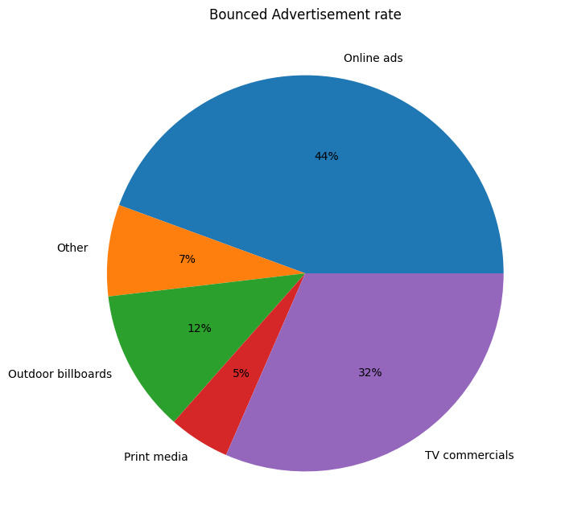

```python
plt.figure(figsize=(12,8))
plt.pie(heard_but_never_tried,labels=heard_but_never_tried.index,autopct='%.0f%%')
plt.title("Bounced Advertisement rate")
```